# Part I - San Francisco Bay Area Ford GoBike Sharing Data

## Preliminary Wrangling

```python
# import all packages and set plots to be embedded inline
import numpy as np
import pandas as pd
import matplotlib.pyplot as plt
import seaborn as sb
import datetime
import pyproj
import fiona
import shapely
import geopandas as gpd
import contextily as cx

%matplotlib inline
```

```python
# Loading dataset into pandas dataframe.
gobike = pd.read_csv('201902-fordgobike-tripdata.csv')
```

```python
# High-level overview of data shape and composition
print(gobike.shape)
print(gobike.dtypes)
```

```
(183412, 16)
duration_sec                 int64
start_time                  object
end_time                    object
start_station_id           float64
start_station_name          object
start_station_latitude     float64
start_station_longitude    float64
end_station_id             float64
end_station_name            object
end_station_latitude       float64
end_station_longitude      float64
bike_id                      int64
user_type                   object
member_birth_year          float64
member_gender               object
bike_share_for_all_trip     object
dtype: object
```

```python
# Sample of 10 entries of dataframe
gobike.sample(10)
```

|  | duration_sec | start_time | end_time | start_station_id | start_station_name | start_station_latitude | start_station_longitude | end_station_id | end_station_name | end_station_latitude | end_station_longitude | bike_id | user_type | member_birth_year | member_gender | bike_share_for_all_trip |
| --- | --- | --- | --- | --- | --- | --- | --- | --- | --- | --- | --- | --- | --- | --- | --- | --- |
| 106186 | 678 | 2019-02-13 18:36:19.4650 | 2019-02-13 18:47:38.4470 | 30.0 | San Francisco Caltrain (Townsend St at 4th St) | 37.776598 | -122.395282 | 75.0 | Market St at Franklin St | 37.773793 | -122.421239 | 4453 | Subscriber | 1986.0 | Male | No |
| 96171 | 167 | 2019-02-15 11:20:44.6450 | 2019-02-15 11:23:32.4550 | 50.0 | 2nd St at Townsend St | 37.780526 | -122.390288 | 28.0 | The Embarcadero at Bryant St | 37.787168 | -122.388098 | 5113 | Subscriber | 1990.0 | Male | No |
| 162771 | 896 | 2019-02-05 10:10:23.9020 | 2019-02-05 10:25:20.7400 | 373.0 | Potrero del Sol Park (25th St at Utah St) | 37.751792 | -122.405216 | 78.0 | Folsom St at 9th St | 37.773717 | -122.411647 | 183 | Subscriber | 1990.0 | Female | No |
| 31998 | 1177 | 2019-02-24 15:13:27.2410 | 2019-02-24 15:33:04.7060 | 171.0 | Rockridge BART Station | 37.844279 | -122.251900 | 150.0 | Adeline St at 40th St | 37.831277 | -122.278267 | 4918 | Subscriber | 1956.0 | Female | No |
| 148662 | 463 | 2019-02-06 21:07:54.4280 | 2019-02-06 21:15:37.6950 | 67.0 | San Francisco Caltrain Station 2 (Townsend St... | 37.776639 | -122.395526 | 126.0 | Esprit Park | 37.761634 | -122.390648 | 5272 | Subscriber | 1994.0 | Male | No |
| 44675 | 152 | 2019-02-22 14:13:10.7120 | 2019-02-22 14:15:43.0500 | 182.0 | 19th Street BART Station | 37.809013 | -122.268247 | 179.0 | Telegraph Ave at 27th St | 37.816073 | -122.267886 | 5236 | Subscriber | 1974.0 | Male | No |
| 111065 | 185 | 2019-02-12 17:31:14.4960 | 2019-02-12 17:34:20.3770 | 58.0 | Market St at 10th St | 37.776619 | -122.417385 | 75.0 | Market St at Franklin St | 37.773793 | -122.421239 | 2458 | Subscriber | 1980.0 | Female | No |
| 151562 | 511 | 2019-02-06 17:09:39.0000 | 2019-02-06 17:18:10.3310 | 363.0 | Salesforce Transit Center (Natoma St at 2nd St) | 37.787492 | -122.398285 | 30.0 | San Francisco Caltrain (Townsend St at 4th St) | 37.776598 | -122.395282 | 5354 | Subscriber | 1970.0 | Male | No |
| 147731 | 281 | 2019-02-07 07:24:51.5320 | 2019-02-07 07:29:32.7240 | 36.0 | Folsom St at 3rd St | 37.783830 | -122.398870 | 67.0 | San Francisco Caltrain Station 2 (Townsend St... | 37.776639 | -122.395526 | 2241 | Subscriber | 1975.0 | Male | Yes |
| 89803 | 622 | 2019-02-16 14:31:45.1810 | 2019-02-16 14:42:07.4870 | 78.0 | Folsom St at 9th St | 37.773717 | -122.411647 | 129.0 | Harrison St at 20th St | 37.758862 | -122.412544 | 5006 | Subscriber | 1989.0 | Female | No |

```python
# Descriptive Statsistics for Numeric columns
gobike.describe()
```

|  | duration_sec | start_station_id | start_station_latitude | start_station_longitude | end_station_id | end_station_latitude | end_station_longitude | bike_id | member_birth_year |
| --- | --- | --- | --- | --- | --- | --- | --- | --- | --- |
| count | 183412.000000 | 183215.000000 | 183412.000000 | 183412.000000 | 183215.000000 | 183412.000000 | 183412.000000 | 183412.000000 | 175147.000000 |
| mean | 726.078435 | 138.590427 | 37.771223 | -122.352664 | 136.249123 | 37.771427 | -122.352250 | 4472.906375 | 1984.806437 |
| std | 1794.389780 | 111.778864 | 0.099581 | 0.117097 | 111.515131 | 0.099490 | 0.116673 | 1664.383394 | 10.116689 |
| min | 61.000000 | 3.000000 | 37.317298 | -122.453704 | 3.000000 | 37.317298 | -122.453704 | 11.000000 | 1878.000000 |
| 25% | 325.000000 | 47.000000 | 37.770083 | -122.412408 | 44.000000 | 37.770407 | -122.411726 | 3777.000000 | 1980.000000 |
| 50% | 514.000000 | 104.000000 | 37.780760 | -122.398285 | 100.000000 | 37.781010 | -122.398279 | 4958.000000 | 1987.000000 |
| 75% | 796.000000 | 239.000000 | 37.797280 | -122.286533 | 235.000000 | 37.797320 | -122.288045 | 5502.000000 | 1992.000000 |
| max | 85444.000000 | 398.000000 | 37.880222 | -121.874119 | 398.000000 | 37.880222 | -121.874119 | 6645.000000 | 2001.000000 |

```python
# Finding columns with null values
gobike.isnull().sum()
```

```
duration_sec                  0
start_time                    0
end_time                      0
start_station_id            197
start_station_name          197
start_station_latitude        0
start_station_longitude       0
end_station_id              197
end_station_name            197
end_station_latitude          0
end_station_longitude         0
bike_id                       0
user_type                     0
member_birth_year          8265
member_gender              8265
bike_share_for_all_trip       0
dtype: int64
```

```python
# Checking if null values in start_station_id have the same  corresponding null vaules in start_station_name
(gobike['start_station_id'].isnull() == gobike['start_station_name'].isnull()).unique()
```

```
array([ True])
```

```python
# Checking if null values in end_station_id have the same corresponding null vaules in end_station_name
(gobike['end_station_id'].isnull() == gobike['end_station_name'].isnull()).unique()
```

```
array([ True])
```

```python
# Checking if null values in member_birth_year have corresponding null vaules in member_gender
(gobike['member_birth_year'].isnull() == gobike['member_gender'].isnull()).unique()
```

```
array([ True])
```

### Data Cleaning

1. Remove null values since they make up about 5% of the dataset ((8265+197)/183413)

#### Code

```python
# Dropping all null values
gobike = gobike.dropna()
```

#### Test

```python
# Confirm all null values have been deleted
gobike.info()
```

```
<class 'pandas.core.frame.DataFrame'>
Int64Index: 174952 entries, 0 to 183411
Data columns (total 16 columns):
 #   Column                   Non-Null Count   Dtype
---  ------                   --------------   -----
 0   duration_sec             174952 non-null  int64
 1   start_time               174952 non-null  object
 2   end_time                 174952 non-null  object
 3   start_station_id         174952 non-null  float64
 4   start_station_name       174952 non-null  object
 5   start_station_latitude   174952 non-null  float64
 6   start_station_longitude  174952 non-null  float64
 7   end_station_id           174952 non-null  float64
 8   end_station_name         174952 non-null  object
 9   end_station_latitude     174952 non-null  float64
 10  end_station_longitude    174952 non-null  float64
 11  bike_id                  174952 non-null  int64
 12  user_type                174952 non-null  object
 13  member_birth_year        174952 non-null  float64
 14  member_gender            174952 non-null  object
 15  bike_share_for_all_trip  174952 non-null  object
dtypes: float64(7), int64(2), object(7)
memory usage: 22.7+ MB
```

2. Change datatypes (start_station_id, end_station_id, bike_id to **strings**), (member_birth_year to **int**) & (member_gender, user_type,bike_share_for_all_trip to **category**)

#### Code

```python
# Converting start_station_id, end_station_id and bike_id to strings
ids = ['start_station_id','end_station_id','bike_id']

for i in ids:

    gobike[i] = gobike[i].astype('str').str[:-2]
```

```python
# Converting member_birth_year to integer so the decimal is removed.
gobike['member_birth_year'] = gobike['member_birth_year'].astype(int)
gobike['start_time'] = pd.to_datetime(gobike['start_time'])
gobike['end_time'] = pd.to_datetime(gobike['end_time'])
```

```python
# Converting member_gender, user_type, bike_share_for_all_trip to category
ordinal_var_dict = {'member_gender': ['Male','Female','Other'],
                    'user_type': ['Customer', 'Subscriber'],
                    'bike_share_for_all_trip': ['No', 'Yes']}

for var in ordinal_var_dict:
    ordered_var = pd.api.types.CategoricalDtype(ordered = True,
                                                categories = ordinal_var_dict[var])
    gobike[var] = gobike[var].astype(ordered_var)
```

#### Test

```python
gobike.info()
```

```
<class 'pandas.core.frame.DataFrame'>
Int64Index: 174952 entries, 0 to 183411
Data columns (total 16 columns):
 #   Column                   Non-Null Count   Dtype
---  ------                   --------------   -----
 0   duration_sec             174952 non-null  int64
 1   start_time               174952 non-null  datetime64[ns]
 2   end_time                 174952 non-null  datetime64[ns]
 3   start_station_id         174952 non-null  object
 4   start_station_name       174952 non-null  object
 5   start_station_latitude   174952 non-null  float64
 6   start_station_longitude  174952 non-null  float64
 7   end_station_id           174952 non-null  object
 8   end_station_name         174952 non-null  object
 9   end_station_latitude     174952 non-null  float64
 10  end_station_longitude    174952 non-null  float64
 11  bike_id                  174952 non-null  object
 12  user_type                174952 non-null  category
 13  member_birth_year        174952 non-null  int32
 14  member_gender            174952 non-null  category
 15  bike_share_for_all_trip  174952 non-null  category
dtypes: category(3), datetime64[ns](2), float64(4), int32(1), int64(1), object(5)
memory usage: 18.5+ MB
```

```python
gobike.head()
```

|  | duration_sec | start_time | end_time | start_station_id | start_station_name | start_station_latitude | start_station_longitude | end_station_id | end_station_name | end_station_latitude | end_station_longitude | bike_id | user_type | member_birth_year | member_gender | bike_share_for_all_trip |
| --- | --- | --- | --- | --- | --- | --- | --- | --- | --- | --- | --- | --- | --- | --- | --- | --- |
| 0 | 52185 | 2019-02-28 17:32:10.145 | 2019-03-01 08:01:55.975 | 21 | Montgomery St BART Station (Market St at 2nd St) | 37.789625 | -122.400811 | 13 | Commercial St at Montgomery St | 37.794231 | -122.402923 | 49 | Customer | 1984 | Male | No |
| 2 | 61854 | 2019-02-28 12:13:13.218 | 2019-03-01 05:24:08.146 | 86 | Market St at Dolores St | 37.769305 | -122.426826 | 3 | Powell St BART Station (Market St at 4th St) | 37.786375 | -122.404904 | 59 | Customer | 1972 | Male | No |
| 3 | 36490 | 2019-02-28 17:54:26.010 | 2019-03-01 04:02:36.842 | 375 | Grove St at Masonic Ave | 37.774836 | -122.446546 | 70 | Central Ave at Fell St | 37.773311 | -122.444293 | 66 | Subscriber | 1989 | Other | No |
| 4 | 1585 | 2019-02-28 23:54:18.549 | 2019-03-01 00:20:44.074 | 7 | Frank H Ogawa Plaza | 37.804562 | -122.271738 | 222 | 10th Ave at E 15th St | 37.792714 | -122.248780 | 48 | Subscriber | 1974 | Male | Yes |
| 5 | 1793 | 2019-02-28 23:49:58.632 | 2019-03-01 00:19:51.760 | 93 | 4th St at Mission Bay Blvd S | 37.770407 | -122.391198 | 323 | Broadway at Kearny | 37.798014 | -122.405950 | 52 | Subscriber | 1959 | Male | No |

#### Code

```python
# Replacing birth year of 1878 with 1978
gobike['member_birth_year'] = gobike['member_birth_year'].replace(to_replace=1878, value=1978)
```

#### Test

```python
gobike[gobike['member_birth_year'] == 1878].count()
```

```
duration_sec               0
start_time                 0
end_time                   0
start_station_id           0
start_station_name         0
start_station_latitude     0
start_station_longitude    0
end_station_id             0
end_station_name           0
end_station_latitude       0
end_station_longitude      0
bike_id                    0
user_type                  0
member_birth_year          0
member_gender              0
bike_share_for_all_trip    0
dtype: int64
```

### What is the structure of your dataset?

> After assessing and cleaning the data, we now have 174952 bike rides on ford gobike system for February 2019.

The data collected include the duration of the bike usage, the start and end times, the start station id and station name as well as the end station id and station name. The longitude and latitudes of the locations. Also captured as the bike ids, user type, member birth year, gender and bike share for all members.

> Almost all data columns need no further explanation with the exception of the user type and Bike_share_for_all.

The user_type captures whether the user is a Customer (One who uses the system when needed but has not signed up for any membership deal)or a Subscriber (one who has a monthly or annual membership deal with ford gobike). Ford GoBike provides discounted annual memberships to qualifying low-income Bay Area residents. These are the Bike_share_for_all beneficiaries.

### What is/are the main feature(s) of interest in your dataset?

> I'm most interested in figuring out relationships and insights concerning the GoBike Stations that will inform the company on where to focus in:
> 1. Improvements to the gobike system
> 2. Advertisements
> 3. Best factors to consider when scaling up the system to other areas

### What features in the dataset do you think will help support your investigation into your feature(s) of interest?

> I suspect the categorical data and station locations given will support my investigation.

## Univariate Exploration

**1. I begin by getting a fair idea of the Gobike rides in the month of February.**

This may not necessarily qualify as a univariate plot but it is a good place to start.

```python
# Groupby start time in days and sum all bike usages in a day.
gobike_feb_usage =gobike.groupby([pd.Grouper(key='start_time', axis=0, freq="D")]).sum('duration_sec')
gobike_feb_usage.head()
```

| start_time | duration_sec | start_station_latitude | start_station_longitude | end_station_latitude | end_station_longitude | member_birth_year |
| --- | --- | --- | --- | --- | --- | --- |
| 2019-02-01 | 3881563 | 220067.089422 | -712915.111574 | 220071.766609 | -712909.197766 | 11564035 |
| 2019-02-02 | 2212314 | 113426.098380 | -367398.428231 | 113427.058397 | -367397.334942 | 5963281 |
| 2019-02-03 | 1918084 | 102300.004970 | -331408.580113 | 102300.379337 | -331408.404935 | 5381087 |
| 2019-02-04 | 3373757 | 199169.132690 | -645148.423965 | 199168.134881 | -645147.019372 | 10465121 |
| 2019-02-05 | 5244936 | 307323.545144 | -995469.681921 | 307324.438391 | -995466.910192 | 16145339 |

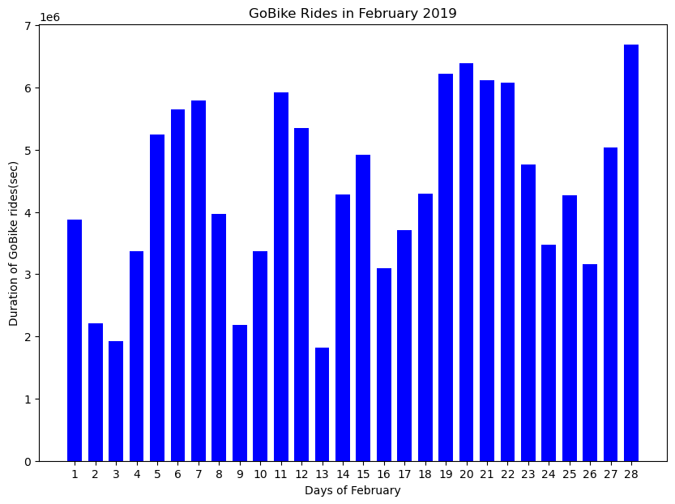

```python
# Standard Plot of GoBike durations to days in the month of February

plt.figure(figsize=[10,7])
plt.bar(x=gobike_feb_usage.index, height=gobike_feb_usage['duration_sec'], color='blue', width=0.7)
plt.xlabel('Days of February')
plt.ylabel('Duration of GoBike rides(sec)')
plt.title('GoBike Rides in February 2019')
labels = list(np.arange(1,29))
plt.xticks(gobike_feb_usage.index, labels)
plt.show()
```

The next set of plots will be exploring the categorical values in the datasets.

**2. Do the Customers or Subscribers patronise GoBike rides more?**

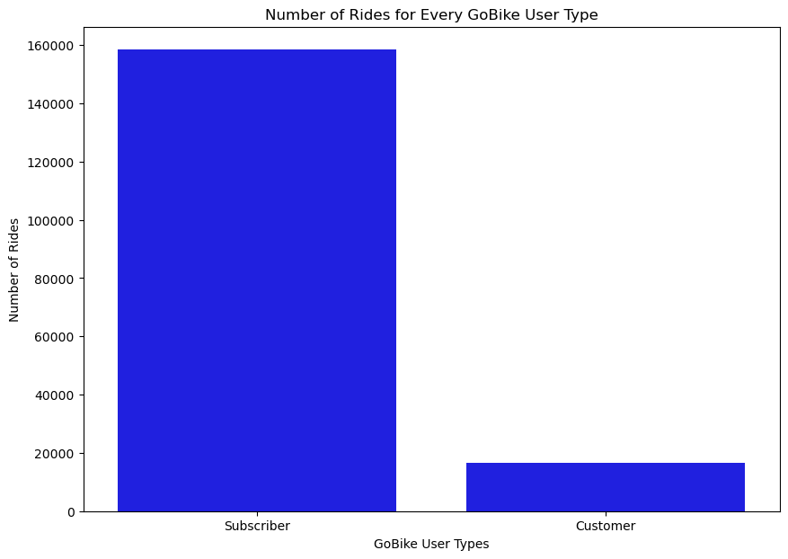

```python
# Plotting the Number of Customer Rides and Subscriber Rides

plt.figure(figsize=[10,7])
sb.countplot(data = gobike, x = 'user_type', color ='blue', order=['Subscriber','Customer'])
plt.xlabel('GoBike User Types')
plt.ylabel('Number of Rides')
plt.title('Number of Rides for Every GoBike User Type')
plt.show()
```

*Most people who patronise GoBike rides have subscribed to the service according to this plot. They either have a monthly or annual membership plan.*

**3. Which gender patronises GoBike rides the most?**

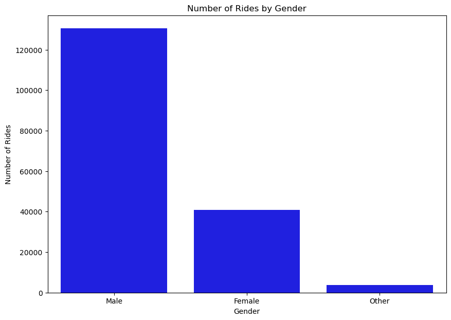

```python
# Plotting the Number of Rides taken by the various genders

plt.figure(figsize=[10,7])
sb.countplot(data = gobike, x = 'member_gender', color ='blue', order=['Male','Female','Other'])
plt.xlabel('Gender')
plt.ylabel('Number of Rides')
plt.title('Number of Rides by Gender')
plt.show()
```

*According to this plot, more rides (Over 120000) in February were taken by men than the other genders. Its however important to mention that this does not emphatically insinuate that more men have taken GoBike rides in February. Fewe men could have contributed to the number of rides. Further exploration should make this clearer*

**4. How many GoBike rides were taken by Discounted members (Bike_Share_For_All)?**

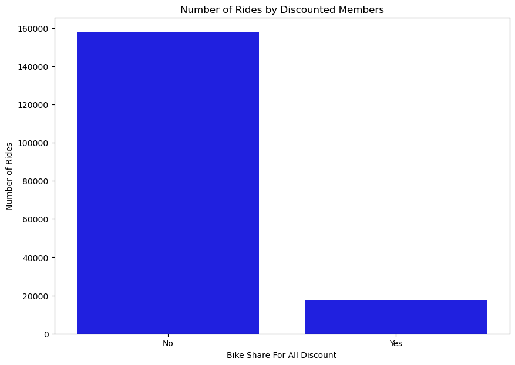

```python
# Plotting the Number of Rides taken by Discounted members

plt.figure(figsize=[10,7])
sb.countplot(data = gobike, x = 'bike_share_for_all_trip', color ='blue')
plt.xlabel('Bike Share For All Discount')
plt.ylabel('Number of Rides')
plt.title('Number of Rides by Discounted Members')
plt.show()
```

*Less than 20000 rides were taken by people who had the Bike Share For All Discount. This could give an indication of the number of Bike Share For All Discounts given in the San Francisco Bay Area*

### Discuss the distribution(s) of your variable(s) of interest. Were there any unusual points? Did you need to perform any transformations?

> In exploring the categorical values, it was realised that the data was very skewed to specific categories. Examaple. There was a huge difference in the number of Subscribers and Customers. Same could be said about the Genders and Bike share For All Discount members. No transformations were done.

### Of the features you investigated, were there any unusual distributions? Did you perform any operations on the data to tidy, adjust, or change the form of the data? If so, why did you do this?

> The first plot, which is not exactly a Univariate plot but was needed to provide the first overview of the data had some grouping done to be able to plot the number of rides according to the days of the month.

> Some Data Assessment and Cleaning was done prior to the initial investigations. Aside these, no adjustment of the data was performed for the Univariate plots.

## Bivariate Exploration

**5. How are the GoBike rides for February distributed across the ages of users**

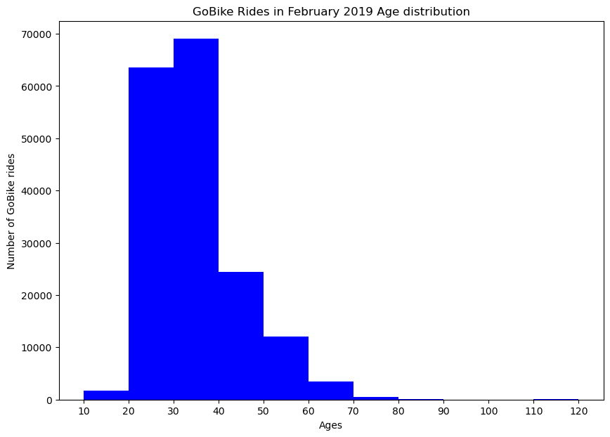

```python
# Plotting the Ages(Decades) of GoBike riders in February
binsize = 10
bins = np.arange(1900, gobike['member_birth_year'].max()+binsize, binsize)

plt.figure(figsize=[10,7])
plt.hist(data=gobike, x='member_birth_year', color='blue', bins=bins)
plt.xlabel('Ages')
plt.ylabel('Number of GoBike rides')
plt.title('GoBike Rides in February 2019 Age distribution')
labels = ['120', '110', '100', '90', '80', '70', '60', '50', '40', '30', '20', '10']
plt.xticks(np.arange(1900,2020,10),labels)
plt.gca().invert_xaxis()
plt.show()
```

*This plot shows that people in their 30's took the most rides in February followed by those in their 20's. The combined number of rides for these two age groups was more than the rest of the age groups. It seems a bit interesting the number of rides taken by young adolescents and teenagers (10-19) is very low.*

**6. Pairwise Correlation between the two useful quantitative variables (Duration of Trips and the Member Birth Year)**

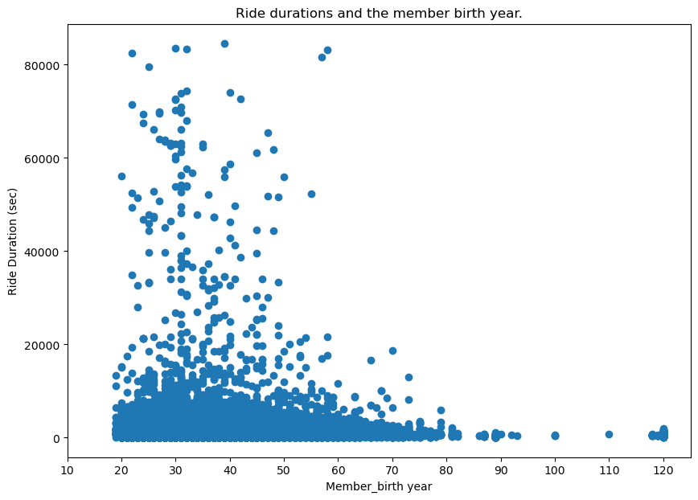

```python
# Scatter plot of Duration of Trips and Member Birth Year

plt.figure(figsize=[10,7])

plt.scatter(data=gobike, x='member_birth_year', y='duration_sec')

plt.xlabel('Member_birth year')
plt.ylabel('Ride Duration (sec)')
plt.title('Ride durations and the member birth year.')
labels = ['120', '110', '100', '90', '80', '70', '60', '50', '40', '30', '20', '10']
plt.xticks(np.arange(1900,2020,10),labels)
plt.gca().invert_xaxis()

plt.show()
```

This is definitely overplotted. the data will be sampled and filtered for data found in the dense area and re-plotted with some alpha and reduced marker size.

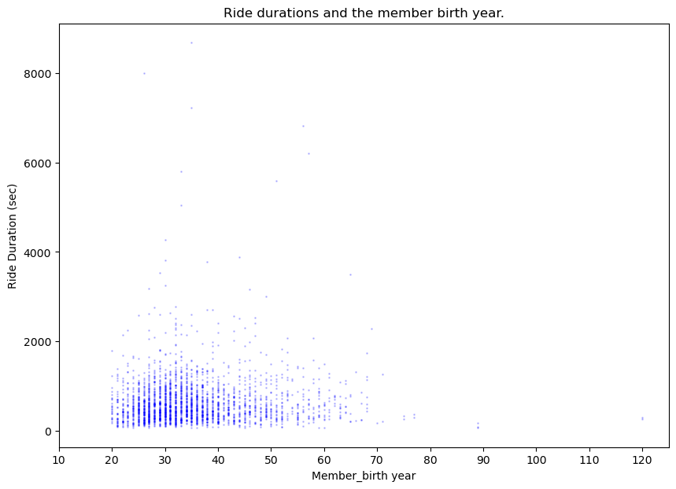

```python
# Scatter plot of Duration of Trips and Member Birth Year

plt.figure(figsize=[10,7])
gobike_sample = gobike.sample(2500)

gobike_sample_filtered = gobike_sample[gobike_sample['duration_sec'] < 10000]
plt.scatter(data=gobike_sample_filtered, x='member_birth_year', y='duration_sec', color='blue',alpha=0.2, s=0.9)

plt.xlabel('Member_birth year')
plt.ylabel('Ride Duration (sec)')
plt.title('Ride durations and the member birth year.')
labels = ['120', '110', '100', '90', '80', '70', '60', '50', '40', '30', '20', '10']
plt.xticks(np.arange(1900,2020,10),labels)
plt.gca().invert_xaxis()

plt.show()
```

*The preceeding plot showed the number of rides compared with the various age groups. This scatter plot here shows the duration of rides compared among the various age groups. A large number of rides were less than 10000 secs (approximately 3 hours) hence the very dense portion of the scatter plot. Some of the longest ride durations were taken by the 20-40 age group. The older the people got, the less time they spent riding. This plot buttresses the earlier one.*

**7. Which GoBike Stations were rides started from the most?**

The dataset has records of the station rides are started from and the station where rides ended. To continue with the next set of explorations, we need to confirm the total number of stations and confirm start_stations are identical to end_stations.(In other words check whether all start stations at one point or another featured as end stations)

```python
# Number of stations rides were started from in the dataset
gobike['start_station_id'].nunique()
```

```
329
```

```python
# Confirm that there are same number of Start Stations as End Stations
gobike['start_station_id'].nunique() == gobike['end_station_id'].nunique()
```

```
True
```

There are same number of stations as start_stations and end_stations.

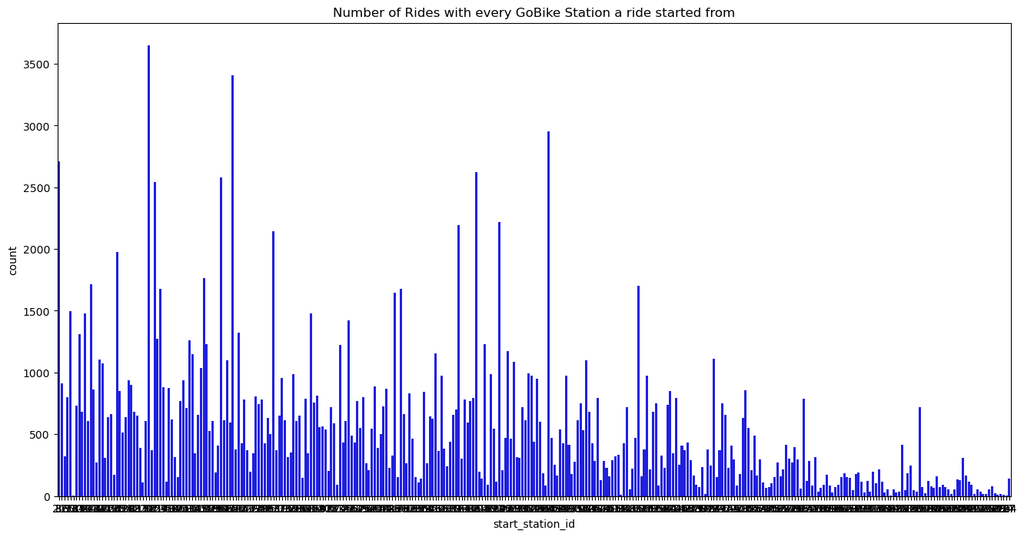

```python
# Plotting the number of rides initiated from all stations
plt.figure(figsize =[16,8])

sb.countplot(data = gobike, x = 'start_station_id', color ='blue')
plt.title('Number of Rides with every GoBike Station a ride started from')
plt.show()
```

*The plot is crowded and impossible to identify labels and make much sense from it. In the subsequent plots, the stations will be sampled or reduced to make it clearer*

**8. Which GoBike Stations did rides end the most?**

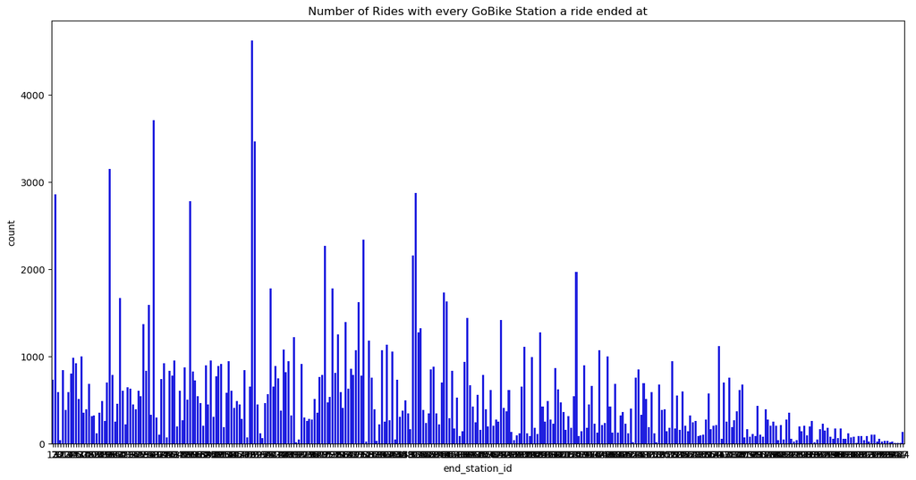

```python
# Plotting the number of rides ended in all stations
plt.figure(figsize =[16,8])

sb.countplot(data = gobike, x = 'end_station_id', color ='blue')
plt.title('Number of Rides with every GoBike Station a ride ended at')
plt.show()
```

*The plot is crowded and impossible to identify labels and make much sense from it. In the subsequent plots, the stations will be sampled or reduced to make it clearer*

```python
# Reducing the plotted stations above to those in the 75th percentile
```

```python
# Groupby start station and sum all bike usages in a day.
gobike_station_start = gobike['start_station_id'].value_counts().reset_index(name='counts')
gobike_station_start.head(5)
```

|  | index | counts |
| --- | --- | --- |
| 0 | 58 | 3649 |
| 1 | 67 | 3408 |
| 2 | 81 | 2952 |
| 3 | 21 | 2711 |
| 4 | 3 | 2620 |

```python
# Summary Statistics
gobike_station_start.describe()
```

|  | counts |
| --- | --- |
| count | 329.000000 |
| mean | 531.768997 |
| std | 551.962376 |
| min | 2.000000 |
| 25% | 155.000000 |
| 50% | 374.000000 |
| 75% | 732.000000 |
| max | 3649.000000 |

```python
# Filtering for rides to start stations that are within the 75th percentile
gobike_most_station_start = gobike_station_start[gobike_station_start['counts'] >= 732]
```

```python
# Groupby end station and sum all bike usages in a day.
gobike_station_end = gobike['end_station_id'].value_counts().reset_index(name='counts')
gobike_station_end.head(5)
```

|  | index | counts |
| --- | --- | --- |
| 0 | 67 | 4624 |
| 1 | 58 | 3709 |
| 2 | 21 | 3461 |
| 3 | 15 | 3151 |
| 4 | 30 | 2870 |

```python
# Summary Statistics
gobike_station_end.describe()
```

|  | counts |
| --- | --- |
| count | 329.000000 |
| mean | 531.768997 |
| std | 598.974134 |
| min | 5.000000 |
| 25% | 160.000000 |
| 50% | 359.000000 |
| 75% | 733.000000 |
| max | 4624.000000 |

```python
#Filtering for rides to end stations that are within the 75th percentile
gobike_most_station_end = gobike_station_end[gobike_station_end['counts'] >= 733]
```

**9. Comparing the GoBike Station with the most start rides and end rides.**

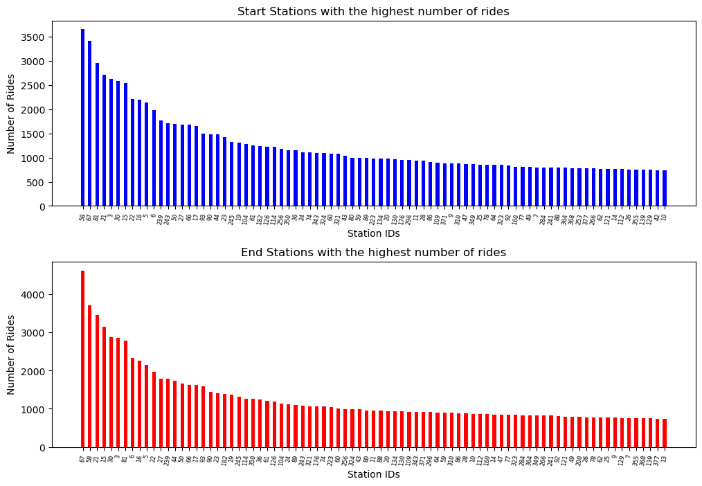

```python
# Plotting the GoBike Station with the highest ride starts and ride ends in two plots for easy comparison

plt.figure(figsize=(12,8))
plt.subplots_adjust(hspace = 0.3)

plt.subplot(2,1,1)
plt.bar(x=gobike_most_station_start['index'], height=gobike_most_station_start['counts'], color='blue', width=0.5)
plt.xticks(fontsize=6, rotation=80)
plt.title('Start Stations with the highest number of rides')
plt.xlabel('Station IDs')
plt.ylabel('Number of Rides')

plt.subplot(2,1,2)
plt.bar(x=gobike_most_station_end['index'], height=gobike_most_station_end['counts'], color='red', width=0.5)
plt.xticks(fontsize=6, rotation=80)
plt.title('End Stations with the highest number of rides')
plt.xlabel('Station IDs')
plt.ylabel('Number of Rides')

plt.show()
```

*The following are the top 10 stations with the highest number of rides starting from.*

> - 58 - Market St at 10th St,*
> - 67 - San Francisco Caltrain Station 2 (Townsend St at 4th St),*
> - 81 - Berry St at 4th St,*
> - 21 - Montgomery St BART Station (Market St and 2nd St),*
> - 3 - Power St BART Station,*
> - 30 - San Francisco Caltrain Station (Townsend St and 4th St),*
> - 15 - San Francisco Ferry Building (Harry Bridges Plaza),*
> - 22 - Howard St at Beale St,*
> - 16 - Steuart St at Market St,*

> *5 - Powell St BART Station (Market St at 5th St)*

*The following are also the top 10 stations with the highest number of rides ending at.*

> - 67 - San Francisco Caltrain Station 2 (Townsend St at 4th St),*
> - 58 - Market St at 10th St,*
> - 21 - Montgomery St BART Station (Market St and 2nd St),*
> - 15 - San Francisco Ferry Building (Harry Bridges Plaza),*
> - 30 - San Francisco Caltrain Station (Townsend St and 4th St),*
> - 3 - Power St BART Station,*
> - 81 - Berry St at 4th St,*
> - 6 - The Embarcadero at Sansome St,*
> - 16 - Steuart St at Market St,*
> - 5 - Powell St BART Station (Market St at 5th St),*

*Comparing the two groups, it can be seen that almost the same stations can be seen in both groups (9/10). This indicates these stations had the highest activity.Trips started and ended at these areas the most*

**10. Comparing the GoBike Station with the least start rides and end rides.**

```python
# Filtering for rides from start stations that are within the 25th percentile
gobike_least_station_start = gobike_station_start[gobike_station_start['counts'] <= 155]
```

```python
# Filtering for rides to end stations that are within the 25th percentile
gobike_least_station_end = gobike_station_end[gobike_station_end['counts'] <= 160]
```

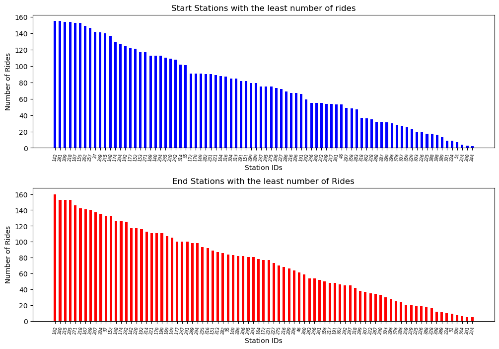

```python
# Plotting the GoBike Station with the least ride starts and ride ends in two plots for easy comparison

plt.figure(figsize=(12,8))
plt.subplots_adjust(hspace = 0.3)

plt.subplot(2,1,1)
plt.bar(x=gobike_least_station_start['index'], height=gobike_least_station_start['counts'], color='blue', width=0.5)
plt.xticks(fontsize=6, rotation=80)
plt.title('Start Stations with the least number of rides')
plt.xlabel('Station IDs')
plt.ylabel('Number of Rides')

plt.subplot(2,1,2)
plt.bar(x=gobike_least_station_end['index'], height=gobike_least_station_end['counts'], color='red', width=0.5)
plt.xticks(fontsize=6, rotation=80)
plt.title('End Stations with the least number of Rides')
plt.xlabel('Station IDs')
plt.ylabel('Number of Rides')

plt.show()
```

*The following are the 10 Start Stations with the least number of rides initiated.*

> - 344 - 16th St Depot*
> - 300 - Palm St at Willow St*
> - 224 - 21st Ave at International Blvd*
> - 51 - Parker Ave at McAllister St*
> - 234 - Farnam St at Fruityale Ave*
> - 301 - Willow St at Vine St*
> - 389 - Taylor St at 9th St*
> - 398 - Leavenworth St at Broadway*
> - 388 - Backesto Park (Jackson St at 13th St)*
> - 225 - 23rd Ave at Foothill Blvd*

*The following are the 10 End Stations where the least number of rides ended.*

*Similar to the earlier plots, the stations with the least number of rides are identical as start stations and end stations. This confirms these stations had the least activity and engagement*

**11. What are the relationships between the categorical features for the stations that record the MOST number of Rides ?**

According to the plots in Q9, the Stations with the MOST number of Rides initiating from are

> 58 - Market St at 10th St 67 - San Francisco Caltrain Station 2 (Townsend St at 4th St) 81 - Berry St at 4th St 21 - Montgomery St BART Station (Market St and 2nd St) 3 - Power St BART Station 30 - San Francisco Caltrain Station (Townsend St and 4th St) 15 - San Francisco Ferry Building (Harry Bridges Plaza)

```python
# Filtering records from only the Top 7 Stations with the most number of rides and saving into a new dataframe.
gobike_top7 = pd.DataFrame()

station_highest = ['58','67','81','21','3','30','15']
for i in station_highest:
    gobike_top7_2 = gobike.loc[gobike['start_station_id'] == i]
    gobike_top7 = pd.concat([gobike_top7,gobike_top7_2])
```

```python
gobike_top7
```

|  | duration_sec | start_time | end_time | start_station_id | start_station_name | start_station_latitude | start_station_longitude | end_station_id | end_station_name | end_station_latitude | end_station_longitude | bike_id | user_type | member_birth_year | member_gender | bike_share_for_all_trip |
| --- | --- | --- | --- | --- | --- | --- | --- | --- | --- | --- | --- | --- | --- | --- | --- | --- |
| 38 | 1066 | 2019-02-28 23:31:16.139 | 2019-02-28 23:49:02.792 | 58 | Market St at 10th St | 37.776619 | -122.417385 | 145 | 29th St at Church St | 37.743684 | -122.426806 | 59 | Subscriber | 1992 | Female | No |
| 54 | 401 | 2019-02-28 23:30:52.471 | 2019-02-28 23:37:33.955 | 58 | Market St at 10th St | 37.776619 | -122.417385 | 62 | Victoria Manalo Draves Park | 37.777791 | -122.406432 | 54 | Subscriber | 1990 | Female | No |
| 110 | 371 | 2019-02-28 23:01:15.077 | 2019-02-28 23:07:26.459 | 58 | Market St at 10th St | 37.776619 | -122.417385 | 98 | Valencia St at 16th St | 37.765052 | -122.421866 | 64 | Subscriber | 1994 | Male | No |
| 114 | 376 | 2019-02-28 23:00:05.223 | 2019-02-28 23:06:21.515 | 58 | Market St at 10th St | 37.776619 | -122.417385 | 21 | Montgomery St BART Station (Market St at 2nd St) | 37.789625 | -122.400811 | 57 | Subscriber | 1982 | Male | No |
| 190 | 515 | 2019-02-28 22:28:11.347 | 2019-02-28 22:36:46.389 | 58 | Market St at 10th St | 37.776619 | -122.417385 | 321 | 5th St at Folsom | 37.780146 | -122.403071 | 52 | Subscriber | 1981 | Other | No |
| ... | ... | ... | ... | ... | ... | ... | ... | ... | ... | ... | ... | ... | ... | ... | ... | ... |
| 183086 | 249 | 2019-02-01 07:12:21.289 | 2019-02-01 07:16:31.000 | 15 | San Francisco Ferry Building (Harry Bridges Pl... | 37.795392 | -122.394203 | 22 | Howard St at Beale St | 37.789756 | -122.394643 | 2 | Subscriber | 1979 | Female | No |
| 183087 | 283 | 2019-02-01 07:11:43.551 | 2019-02-01 07:16:26.720 | 15 | San Francisco Ferry Building (Harry Bridges Pl... | 37.795392 | -122.394203 | 20 | Mechanics Monument Plaza (Market St at Bush St) | 37.791300 | -122.399051 | 26 | Subscriber | 1979 | Male | No |
| 183096 | 376 | 2019-02-01 07:08:12.092 | 2019-02-01 07:14:28.838 | 15 | San Francisco Ferry Building (Harry Bridges Pl... | 37.795392 | -122.394203 | 6 | The Embarcadero at Sansome St | 37.804770 | -122.403234 | 10 | Subscriber | 1963 | Female | No |
| 183148 | 395 | 2019-02-01 06:53:22.285 | 2019-02-01 06:59:57.987 | 15 | San Francisco Ferry Building (Harry Bridges Pl... | 37.795392 | -122.394203 | 6 | The Embarcadero at Sansome St | 37.804770 | -122.403234 | 30 | Subscriber | 1964 | Female | No |
| 183222 | 191 | 2019-02-01 06:32:38.467 | 2019-02-01 06:35:50.222 | 15 | San Francisco Ferry Building (Harry Bridges Pl... | 37.795392 | -122.394203 | 20 | Mechanics Monument Plaza (Market St at Bush St) | 37.791300 | -122.399051 | 31 | Subscriber | 1947 | Male | No |

20458 rows × 16 columns

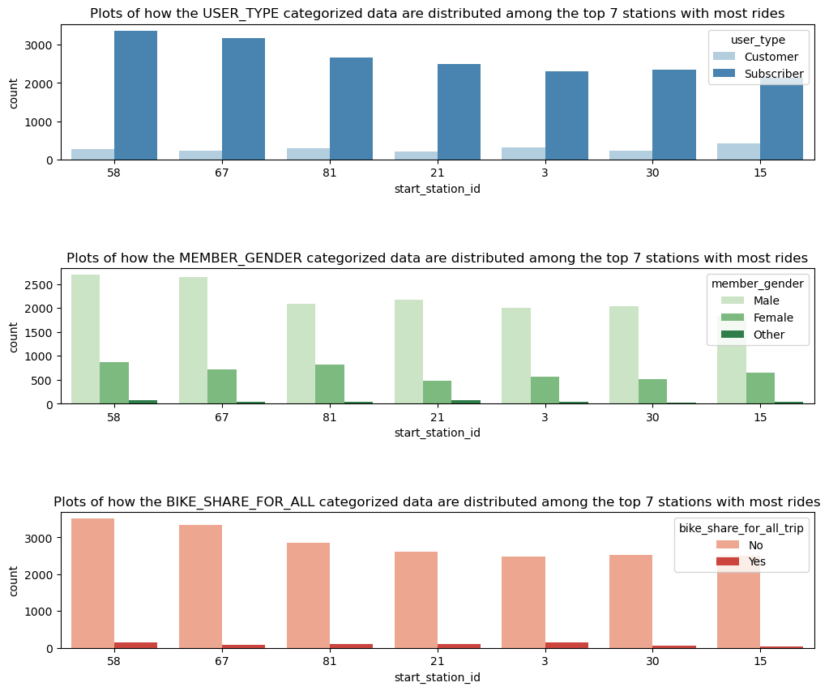

```python
# Plotting the relationship between the user_type, member_gender and bike_share_for_all for each of the top 7 stations
plt.figure(figsize = [12,10])
plt.subplots_adjust(hspace =0.8)


#subplot1:
plt.subplot(3,1,1)
sb.countplot(data = gobike_top7, x = 'start_station_id', hue='user_type', palette = 'Blues')
plt.xticks()
plt.title('Plots of how the USER_TYPE categorized data are distributed among the top 7 stations with most rides')

#subplot2:
plt.subplot(3,1,2)
sb.countplot(data = gobike_top7, x = 'start_station_id', hue='member_gender', palette = 'Greens')
plt.xticks()
plt.title('Plots of how the MEMBER_GENDER categorized data are distributed among the top 7 stations with most rides')


#subplot3:
plt.subplot(3,1,3)
sb.countplot(data = gobike_top7, x = 'start_station_id', hue='bike_share_for_all_trip', palette = 'Reds')
plt.xticks()
plt.title('Plots of how the BIKE_SHARE_FOR_ALL categorized data are distributed among the top 7 stations with most rides')

plt.show()
```

*Just as expected, the plots for the categorical values of the top 7 Stations agrees with the general plot of categorical values seen in the Univariate plots.*

**12. Relationships between the categorical features for the stations that record the LEAST rides.**

> - 344-16th St Depot,
> - 300-Palm St at Willow St,
> - 224-21st Ave at International Blvd,
> - 51-Parker Ave at McAllister St,
> - 234-Farnam St at Fruityale Ave,
> - 301-Willow St at Vine St,
> - 389-Taylor St at 9th St,

```python
gobike_bottom7 = pd.DataFrame()

station_lowest = ['344','300','224','51','234','301','389']
for i in station_lowest:
    gobike_bottom7_2 = gobike.loc[gobike['start_station_id'] == i]
    gobike_bottom7 = pd.concat([gobike_bottom7,gobike_bottom7_2])
```

```python
gobike_bottom7
```

|  | duration_sec | start_time | end_time | start_station_id | start_station_name | start_station_latitude | start_station_longitude | end_station_id | end_station_name | end_station_latitude | end_station_longitude | bike_id | user_type | member_birth_year | member_gender | bike_share_for_all_trip |
| --- | --- | --- | --- | --- | --- | --- | --- | --- | --- | --- | --- | --- | --- | --- | --- | --- |
| 3157 | 735 | 2019-02-28 17:26:33.008 | 2019-02-28 17:38:48.782 | 344 | 16th St Depot | 37.766349 | -122.396292 | 23 | The Embarcadero at Steuart St | 37.791464 | -122.391034 | 44 | Subscriber | 1985 | Male | No |
| 112654 | 530 | 2019-02-12 14:42:32.684 | 2019-02-12 14:51:22.838 | 344 | 16th St Depot | 37.766349 | -122.396292 | 61 | Howard St at 8th St | 37.776513 | -122.411306 | 61 | Subscriber | 1990 | Male | No |
| 6 | 1147 | 2019-02-28 23:55:35.104 | 2019-03-01 00:14:42.588 | 300 | Palm St at Willow St | 37.317298 | -121.884995 | 312 | San Jose Diridon Station | 37.329732 | -121.901782 | 38 | Subscriber | 1983 | Female | No |
| 25767 | 3135 | 2019-02-25 15:26:20.425 | 2019-02-25 16:18:35.555 | 300 | Palm St at Willow St | 37.317298 | -121.884995 | 35 | Cahill Park | 37.329119 | -121.904576 | 40 | Subscriber | 1994 | Male | Yes |
| 25768 | 3120 | 2019-02-25 15:26:34.784 | 2019-02-25 16:18:35.472 | 300 | Palm St at Willow St | 37.317298 | -121.884995 | 35 | Cahill Park | 37.329119 | -121.904576 | 37 | Subscriber | 1993 | Male | Yes |
| 88038 | 855 | 2019-02-16 20:22:57.353 | 2019-02-16 20:37:13.258 | 224 | 21st Ave at International Blvd | 37.784855 | -122.239305 | 200 | 2nd Ave at E 18th St | 37.800214 | -122.253810 | 51 | Subscriber | 1972 | Male | Yes |
| 148696 | 380 | 2019-02-06 21:03:57.625 | 2019-02-06 21:10:17.771 | 224 | 21st Ave at International Blvd | 37.784855 | -122.239305 | 222 | 10th Ave at E 15th St | 37.792714 | -122.248780 | 44 | Subscriber | 1977 | Male | No |
| 153276 | 2011 | 2019-02-06 12:41:07.077 | 2019-02-06 13:14:38.733 | 224 | 21st Ave at International Blvd | 37.784855 | -122.239305 | 153 | 59th St at Horton St | 37.840945 | -122.291360 | 45 | Subscriber | 1997 | Male | No |
| 154628 | 802 | 2019-02-06 09:27:37.017 | 2019-02-06 09:40:59.183 | 224 | 21st Ave at International Blvd | 37.784855 | -122.239305 | 221 | 6th Ave at E 12th St (Temporary Location) | 37.794396 | -122.253842 | 45 | Customer | 1990 | Male | No |
| 561 | 724 | 2019-02-28 20:58:29.271 | 2019-02-28 21:10:34.156 | 51 | Parker Ave at McAllister St | 37.776101 | -122.453093 | 43 | San Francisco Public Library (Grove St at Hyde... | 37.778768 | -122.415929 | 52 | Subscriber | 1989 | Male | No |
| 952 | 147 | 2019-02-28 20:06:50.116 | 2019-02-28 20:09:18.104 | 51 | Parker Ave at McAllister St | 37.776101 | -122.453093 | 380 | Masonic Ave at Turk St | 37.779047 | -122.447291 | 43 | Subscriber | 1995 | Male | No |
| 4887 | 145 | 2019-02-28 14:46:36.365 | 2019-02-28 14:49:02.289 | 51 | Parker Ave at McAllister St | 37.776101 | -122.453093 | 377 | Fell St at Stanyan St | 37.771917 | -122.453704 | 4 | Subscriber | 1978 | Other | No |
| 4902 | 480 | 2019-02-28 14:37:22.295 | 2019-02-28 14:45:22.832 | 51 | Parker Ave at McAllister St | 37.776101 | -122.453093 | 71 | Broderick St at Oak St | 37.773063 | -122.439078 | 50 | Subscriber | 1988 | Male | No |
| 6548 | 1592 | 2019-02-28 09:43:55.762 | 2019-02-28 10:10:28.540 | 51 | Parker Ave at McAllister St | 37.776101 | -122.453093 | 28 | The Embarcadero at Bryant St | 37.787168 | -122.388098 | 53 | Customer | 1990 | Female | No |
| 8467 | 879 | 2019-02-28 08:14:07.980 | 2019-02-28 08:28:47.531 | 51 | Parker Ave at McAllister St | 37.776101 | -122.453093 | 101 | 15th St at Potrero Ave | 37.767079 | -122.407359 | 58 | Subscriber | 1982 | Male | No |
| 8801 | 1494 | 2019-02-28 07:47:24.484 | 2019-02-28 08:12:18.815 | 51 | Parker Ave at McAllister St | 37.776101 | -122.453093 | 336 | Potrero Ave and Mariposa St | 37.763281 | -122.407377 | 65 | Customer | 1993 | Female | No |
| 34695 | 1911 | 2019-02-23 21:35:28.703 | 2019-02-23 22:07:19.805 | 234 | Farnam St at Fruitvale Ave | 37.778058 | -122.225400 | 227 | Foothill Blvd at Fruitvale Ave | 37.783757 | -122.222603 | 46 | Subscriber | 1992 | Female | No |
| 38267 | 1566 | 2019-02-23 12:03:02.087 | 2019-02-23 12:29:08.452 | 234 | Farnam St at Fruitvale Ave | 37.778058 | -122.225400 | 197 | El Embarcadero at Grand Ave | 37.808848 | -122.249680 | 32 | Subscriber | 1981 | Female | No |
| 69046 | 146 | 2019-02-19 20:26:31.921 | 2019-02-19 20:28:58.914 | 234 | Farnam St at Fruitvale Ave | 37.778058 | -122.225400 | 237 | Fruitvale BART Station | 37.775232 | -122.224498 | 46 | Customer | 2000 | Male | No |
| 69227 | 2610 | 2019-02-19 19:21:02.321 | 2019-02-19 20:04:32.501 | 234 | Farnam St at Fruitvale Ave | 37.778058 | -122.225400 | 234 | Farnam St at Fruitvale Ave | 37.778058 | -122.225400 | 46 | Customer | 1983 | Male | No |
| 69528 | 368 | 2019-02-19 19:21:35.367 | 2019-02-19 19:27:43.562 | 234 | Farnam St at Fruitvale Ave | 37.778058 | -122.225400 | 237 | Fruitvale BART Station | 37.775232 | -122.224498 | 66 | Customer | 2000 | Male | No |
| 140787 | 382 | 2019-02-07 18:40:18.350 | 2019-02-07 18:46:41.277 | 234 | Farnam St at Fruitvale Ave | 37.778058 | -122.225400 | 228 | Foothill Blvd at Harrington Ave | 37.779930 | -122.217728 | 25 | Customer | 1988 | Male | No |
| 171728 | 544 | 2019-02-03 19:14:49.581 | 2019-02-03 19:23:53.849 | 234 | Farnam St at Fruitvale Ave | 37.778058 | -122.225400 | 227 | Foothill Blvd at Fruitvale Ave | 37.783757 | -122.222603 | 19 | Subscriber | 1992 | Female | No |
| 175040 | 1292 | 2019-02-02 15:34:56.514 | 2019-02-02 15:56:28.896 | 234 | Farnam St at Fruitvale Ave | 37.778058 | -122.225400 | 197 | El Embarcadero at Grand Ave | 37.808848 | -122.249680 | 34 | Subscriber | 1989 | Female | No |
| 175043 | 1265 | 2019-02-02 15:34:37.605 | 2019-02-02 15:55:43.353 | 234 | Farnam St at Fruitvale Ave | 37.778058 | -122.225400 | 197 | El Embarcadero at Grand Ave | 37.808848 | -122.249680 | 36 | Subscriber | 1988 | Male | No |
| 27232 | 515 | 2019-02-25 09:56:11.953 | 2019-02-25 10:04:47.090 | 301 | Willow St at Vine St | 37.318450 | -121.883172 | 327 | 5th St at San Salvador St | 37.332039 | -121.881766 | 15 | Customer | 1987 | Female | No |
| 63082 | 785 | 2019-02-20 15:52:09.653 | 2019-02-20 16:05:15.323 | 301 | Willow St at Vine St | 37.318450 | -121.883172 | 278 | The Alameda at Bush St | 37.331932 | -121.904888 | 40 | Subscriber | 1993 | Male | Yes |
| 74600 | 469 | 2019-02-19 10:00:45.075 | 2019-02-19 10:08:34.640 | 301 | Willow St at Vine St | 37.318450 | -121.883172 | 296 | 5th St at Virginia St | 37.325998 | -121.877120 | 66 | Subscriber | 1995 | Male | Yes |
| 82736 | 560 | 2019-02-18 09:12:46.891 | 2019-02-18 09:22:07.878 | 301 | Willow St at Vine St | 37.318450 | -121.883172 | 296 | 5th St at Virginia St | 37.325998 | -121.877120 | 38 | Subscriber | 1995 | Male | Yes |
| 116754 | 3638 | 2019-02-12 06:27:01.097 | 2019-02-12 07:27:39.108 | 301 | Willow St at Vine St | 37.318450 | -121.883172 | 298 | Oak St at 1st St | 37.322125 | -121.881090 | 42 | Subscriber | 1991 | Male | No |
| 125921 | 1745 | 2019-02-10 23:09:19.774 | 2019-02-10 23:38:25.272 | 301 | Willow St at Vine St | 37.318450 | -121.883172 | 298 | Oak St at 1st St | 37.322125 | -121.881090 | 38 | Subscriber | 1991 | Male | No |
| 132145 | 530 | 2019-02-09 09:24:02.334 | 2019-02-09 09:32:53.228 | 301 | Willow St at Vine St | 37.318450 | -121.883172 | 283 | Delmas Ave and San Fernando St | 37.330264 | -121.897702 | 40 | Subscriber | 1991 | Male | No |
| 153493 | 1206 | 2019-02-06 12:19:06.560 | 2019-02-06 12:39:12.704 | 301 | Willow St at Vine St | 37.318450 | -121.883172 | 289 | 5th St at Taylor St | 37.351017 | -121.895921 | 38 | Subscriber | 1957 | Male | Yes |
| 161798 | 800 | 2019-02-05 13:37:30.915 | 2019-02-05 13:50:50.926 | 301 | Willow St at Vine St | 37.318450 | -121.883172 | 301 | Willow St at Vine St | 37.318450 | -121.883172 | 38 | Subscriber | 1989 | Male | No |
| 7448 | 2314 | 2019-02-28 08:33:16.679 | 2019-02-28 09:11:51.300 | 389 | Taylor St at 9th St | 37.353062 | -121.891937 | 389 | Taylor St at 9th St | 37.353062 | -121.891937 | 61 | Customer | 1989 | Other | No |
| 7453 | 2302 | 2019-02-28 08:33:16.534 | 2019-02-28 09:11:38.745 | 389 | Taylor St at 9th St | 37.353062 | -121.891937 | 389 | Taylor St at 9th St | 37.353062 | -121.891937 | 61 | Customer | 1989 | Other | No |
| 12125 | 727 | 2019-02-27 17:48:49.598 | 2019-02-27 18:00:57.125 | 389 | Taylor St at 9th St | 37.353062 | -121.891937 | 311 | Paseo De San Antonio at 2nd St | 37.333798 | -121.886943 | 25 | Customer | 1987 | Male | No |
| 35974 | 1004 | 2019-02-23 17:09:03.065 | 2019-02-23 17:25:47.817 | 389 | Taylor St at 9th St | 37.353062 | -121.891937 | 276 | Julian St at The Alameda | 37.332233 | -121.912516 | 1 | Customer | 1974 | Male | No |
| 45150 | 909 | 2019-02-22 12:46:30.949 | 2019-02-22 13:01:40.103 | 389 | Taylor St at 9th St | 37.353062 | -121.891937 | 308 | San Pedro Square | 37.336802 | -121.894090 | 61 | Subscriber | 1959 | Male | No |
| 52674 | 276 | 2019-02-21 17:02:58.242 | 2019-02-21 17:07:34.627 | 389 | Taylor St at 9th St | 37.353062 | -121.891937 | 292 | Empire St at 1st St | 37.344882 | -121.896965 | 40 | Subscriber | 1988 | Male | No |
| 52809 | 3324 | 2019-02-21 16:03:13.109 | 2019-02-21 16:58:37.715 | 389 | Taylor St at 9th St | 37.353062 | -121.891937 | 280 | San Fernando St at 7th St | 37.337122 | -121.883215 | 40 | Subscriber | 1982 | Male | Yes |
| 54385 | 574 | 2019-02-21 12:58:04.133 | 2019-02-21 13:07:38.429 | 389 | Taylor St at 9th St | 37.353062 | -121.891937 | 308 | San Pedro Square | 37.336802 | -121.894090 | 38 | Subscriber | 1959 | Male | No |
| 62800 | 437 | 2019-02-20 16:25:50.334 | 2019-02-20 16:33:08.286 | 389 | Taylor St at 9th St | 37.353062 | -121.891937 | 310 | San Fernando St at 4th St | 37.335885 | -121.885660 | 66 | Subscriber | 1988 | Male | No |
| 63928 | 540 | 2019-02-20 13:25:13.493 | 2019-02-20 13:34:14.108 | 389 | Taylor St at 9th St | 37.353062 | -121.891937 | 308 | San Pedro Square | 37.336802 | -121.894090 | 63 | Subscriber | 1959 | Male | No |
| 73417 | 568 | 2019-02-19 13:49:37.343 | 2019-02-19 13:59:06.195 | 389 | Taylor St at 9th St | 37.353062 | -121.891937 | 311 | Paseo De San Antonio at 2nd St | 37.333798 | -121.886943 | 62 | Subscriber | 1988 | Male | No |
| 88041 | 745 | 2019-02-16 20:23:10.337 | 2019-02-16 20:35:35.337 | 389 | Taylor St at 9th St | 37.353062 | -121.891937 | 313 | Almaden Blvd at San Fernando St | 37.331415 | -121.893200 | 62 | Customer | 1969 | Male | No |
| 102479 | 803 | 2019-02-14 16:19:55.621 | 2019-02-14 16:33:18.646 | 389 | Taylor St at 9th St | 37.353062 | -121.891937 | 327 | 5th St at San Salvador St | 37.332039 | -121.881766 | 37 | Subscriber | 1994 | Female | Yes |

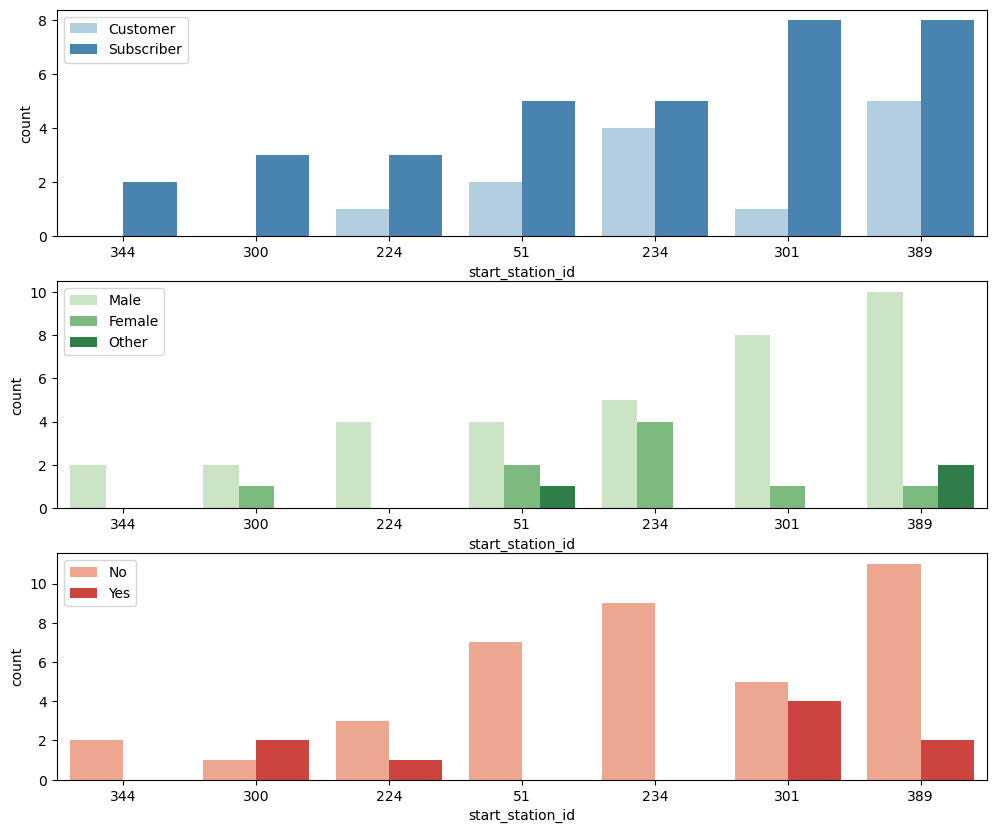

```python
# Plotting the relationship between the user_type, member_gender and bike_share_for_all for each of the lowest stations
plt.figure(figsize = [12,10])
plt.subplots_adjust(hspace =0.2)

#subplot1:
plt.subplot(3,1,1)
sb.countplot(data = gobike_bottom7, x = 'start_station_id', hue='user_type', palette = 'Blues')
plt.xticks()
plt.legend(loc = "upper left")

#subplot2:
plt.subplot(3,1,2)
sb.countplot(data = gobike_bottom7, x = 'start_station_id', hue='member_gender', palette = 'Greens')
plt.xticks()
plt.legend(loc = "upper left")

#subplot3:
plt.subplot(3,1,3)
sb.countplot(data = gobike_bottom7, x = 'start_station_id', hue='bike_share_for_all_trip', palette = 'Reds')
plt.xticks()
plt.legend(loc = "upper left")

plt.show()
```

*From the above subplots, it can be seen that some of the stations do not have the varied categories. Station 344 - 16th St Depot with the least number of rides has only two subscribers (no customers) who took rides in February, out of those rides, they were all males and were not Bike Share for All discount receipients. Other stations with no Bike Share for All discount members were 51-Pat Ave at McAalister St.and 234-Farnam St at Fruityale Ave.*

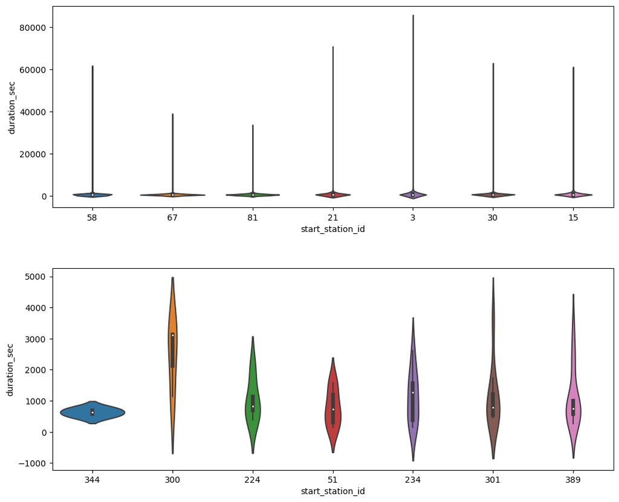

```python
# Still considering the Top 7 and Least 7 Stations, I used a violinplot to show the cummulative distance covered by the rides
plt.figure(figsize = [12,10])
plt.subplots_adjust(hspace = 0.3)

plt.subplot(2,1,1)
ax1 = sb.violinplot(data=gobike_top7, x='start_station_id', y='duration_sec')

plt.subplot(2,1,2)
ax1 = sb.violinplot(data=gobike_bottom7, x='start_station_id', y='duration_sec')
```

**14. Where are the stations with the highest and least number of rides actually located?**

Could the location of the stations be a factor to their patronage. This will be explored by plotting the coordinates of the Top 7 Stations with the MOST rides and Bottom 7 Stations with the LEAST rides on the actual San Francisco Bay Area Map.

```python
# Filtering all duplicated start station id's so the dataframe is reduced according to the unique station ids with the MOST number of rides
gobike_top7_map = gobike_top7.drop_duplicates(subset = ['start_station_id'])
```

```python
# Filtering all duplicated start station id's so the dataframe is reduced according to the unique station ids with the LEAST number of rides
gobike_bottom7_map = gobike_bottom7.drop_duplicates(subset = ['start_station_id'])
```

```python
# Creating GeoPandas GeoDataFrame which has the 'plottable' coordinates derived from the latitudes and longitudes added as the last column (geometry)
gobike_top7_gdf = gpd.GeoDataFrame(gobike_top7_map, geometry = gpd.points_from_xy(gobike_top7_map['start_station_longitude'],gobike_top7_map['start_station_latitude']))
gobike_bottom7_gdf = gpd.GeoDataFrame(gobike_bottom7_map, geometry = gpd.points_from_xy(gobike_bottom7_map['start_station_longitude'],gobike_bottom7_map['start_station_latitude']))
```

```python
gobike_top7_gdf.head(2)
```

|  | duration_sec | start_time | end_time | start_station_id | start_station_name | start_station_latitude | start_station_longitude | end_station_id | end_station_name | end_station_latitude | end_station_longitude | bike_id | user_type | member_birth_year | member_gender | bike_share_for_all_trip | geometry |
| --- | --- | --- | --- | --- | --- | --- | --- | --- | --- | --- | --- | --- | --- | --- | --- | --- | --- |
| 38 | 1066 | 2019-02-28 23:31:16.139 | 2019-02-28 23:49:02.792 | 58 | Market St at 10th St | 37.776619 | -122.417385 | 145 | 29th St at Church St | 37.743684 | -122.426806 | 59 | Subscriber | 1992 | Female | No | POINT (-122.41738 37.77662) |
| 85 | 73 | 2019-02-28 23:17:06.483 | 2019-02-28 23:18:19.711 | 67 | San Francisco Caltrain Station 2 (Townsend St... | 37.776639 | -122.395526 | 80 | Townsend St at 5th St | 37.775235 | -122.397437 | 50 | Subscriber | 1995 | Male | No | POINT (-122.39553 37.77664) |

```python
gobike_bottom7_gdf.head(2)
```

|  | duration_sec | start_time | end_time | start_station_id | start_station_name | start_station_latitude | start_station_longitude | end_station_id | end_station_name | end_station_latitude | end_station_longitude | bike_id | user_type | member_birth_year | member_gender | bike_share_for_all_trip | geometry |
| --- | --- | --- | --- | --- | --- | --- | --- | --- | --- | --- | --- | --- | --- | --- | --- | --- | --- |
| 3157 | 735 | 2019-02-28 17:26:33.008 | 2019-02-28 17:38:48.782 | 344 | 16th St Depot | 37.766349 | -122.396292 | 23 | The Embarcadero at Steuart St | 37.791464 | -122.391034 | 44 | Subscriber | 1985 | Male | No | POINT (-122.39629 37.76635) |
| 6 | 1147 | 2019-02-28 23:55:35.104 | 2019-03-01 00:14:42.588 | 300 | Palm St at Willow St | 37.317298 | -121.884995 | 312 | San Jose Diridon Station | 37.329732 | -121.901782 | 38 | Subscriber | 1983 | Female | No | POINT (-121.88500 37.31730) |

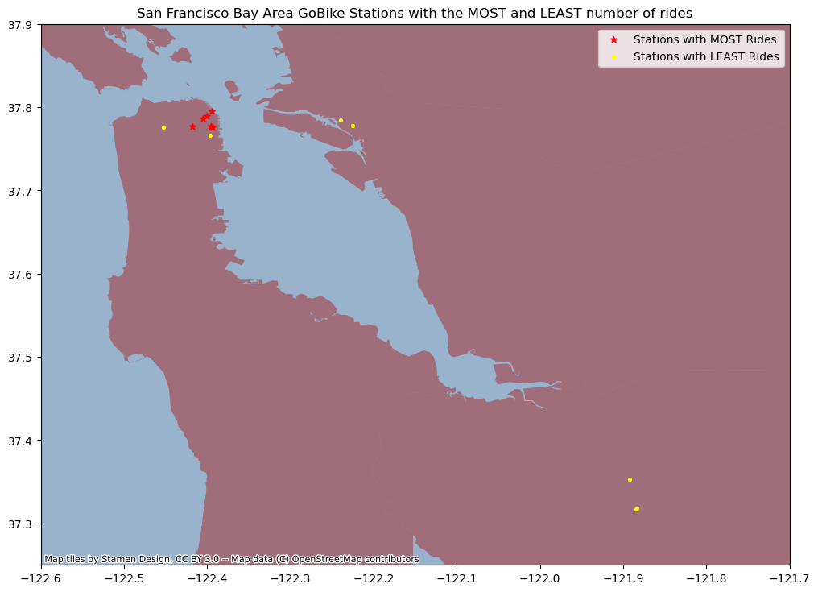

```python
# Plotting the San Francisco Bay Area GoBike Stations with MOST rides and LEAST rides on a map (shapefile)

#Reading map file with geopandas
san_francisco_bay_map = gpd.read_file('map/bayarea_county.shp')

#Creating subplots and placing 3 plots on one another (Bay Area Map, Coordinates of Top 7 Stations and Coordinates of Bottom 7 Stations)
fig,ax = plt.subplots(figsize = (12,12))
san_francisco_bay_map.to_crs(epsg=4326).plot(ax=ax, alpha=0.5, color = 'brown')
gobike_top7_gdf.plot(ax = ax, markersize = 30, color = 'red', marker = '*')
gobike_bottom7_gdf.plot(ax = ax, markersize = 30, color = 'yellow',marker = '.')

cx.add_basemap(ax)
ax.set_xlim([-122.6, -121.7])
ax.set_ylim([37.25, 37.9])

ax.set_title('San Francisco Bay Area GoBike Stations with the MOST and LEAST number of rides')
plt.legend(['Stations with MOST Rides', 'Stations with LEAST Rides'])

plt.show()
```

### Talk about some of the relationships you observed in this part of the investigation. How did the feature(s) of interest vary with other features in the dataset?

> The first two plots considering the relationship between GoBike usage and the age of the users showed that the most users fell between the ages of 20-40. This is likely due to the atheletism associated with such young age. This could be an area of focus for advertisement. Eventhough I expected a high usage among adolescent and teenages, this was not the case. This could further be investigated and exploited.

> Third if the interest of the other genders could be raised, the patronage will increase. Men contributed the highest in the usage of the GoBike system and while it may seem explainable, the numbers of females once increased, will directly improve the usage.

### Did you observe any interesting relationships between the other features (not the main feature(s) of interest)?

> The Locations of the stations were not some of the features I initially had my eyes on, but they seem to be affecting the usage of the GoBike System.

## Multivariate Exploration

further. Make sure that your investigations are justified, and follow from your work in the previous sections.

**15. Does the distance always affect ride durations?**

I am going to do one last investigation on the ride durations. I will looking for a proof that the distance is a determinant in the ride durations. I will start by finding the distance covered in each ride and then plot it agains the duration for each of the top 7 and least 7 stations.

```python
# Importing geodesic for calculation of distance between two points given the latitudes and longitudes.
from geopy.distance import geodesic
```

```python
# Get the latitude and longitude rows and return the calculated distance with the geodesic method and save in new dataframe column
def distancer(row):
    coords_1 = (row['start_station_latitude'], row['start_station_longitude'])
    coords_2 = (row['end_station_latitude'], row['end_station_longitude'])
    return geodesic(coords_1, coords_2).km

gobike_top7['distance_km'] = gobike_top7.apply(distancer, axis=1)
```

```python
# Rounding off distance (km) to 2 decimal places.
gobike_top7['distance_km'] = gobike_top7['distance_km'].round(decimals=2)
```

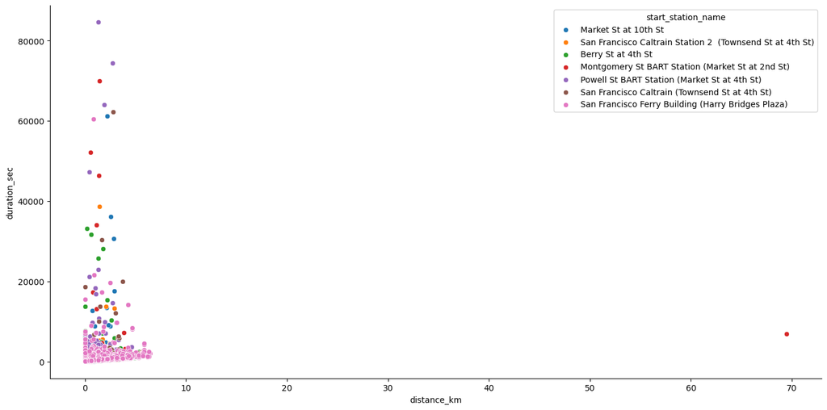

```python
# Plotting a facetted scatterplot with different colours showing the various Stations
multi = sb.FacetGrid(data = gobike_top7, hue='start_station_name', height =7, aspect=2,legend_out=False)
multi.map_dataframe(sb.scatterplot, x='distance_km', y='duration_sec', alpha=1)
multi.add_legend()
```

An outlier in this plot is making it difficult to interpret it. A ride from Montgomery St BART Station(Market St and 2nd St) covered almost 70km in about 2 hours. This seems a little out of place since the average biker rides 23-29km/h according to http://bikelockwiki.com/average-cycling-speed. This entry will be dropped and the dataframe re-plotted.

```python
# Deleting the outlier
gobike_top7 = gobike_top7[gobike_top7['distance_km'] < 60]
```

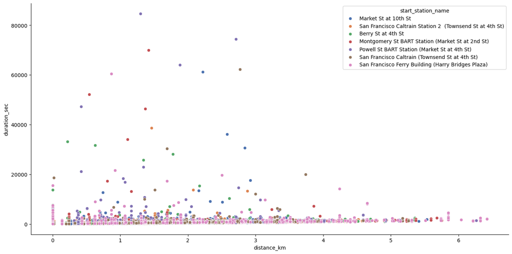

```python
# Plotting a facetted scatterplot with different colours showing the various Stations
multi = sb.FacetGrid(data = gobike_top7, hue='start_station_name',height=7, aspect=2, palette='deep', legend_out=False)
multi.map_dataframe(sb.scatterplot, x='distance_km', y='duration_sec')
multi.add_legend()
```

```python
# Get the latitude and longitude rows and return the calculated distance with the geodesic method and save in new dataframe column
def distancer(row):
    coords_1 = (row['start_station_latitude'], row['start_station_longitude'])
    coords_2 = (row['end_station_latitude'], row['end_station_longitude'])
    return geodesic(coords_1, coords_2).km

gobike_bottom7['distance_km'] = gobike_bottom7.apply(distancer, axis=1)
```

```python
# Rounding off distance (km) to 2 decimal places.
gobike_bottom7['distance_km'] = gobike_bottom7['distance_km'].round(decimals=2)
```

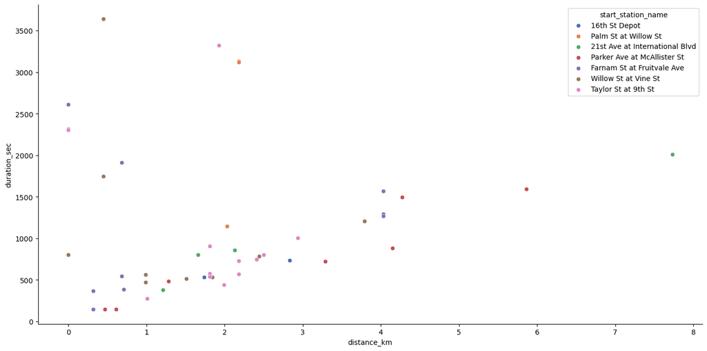

```python
# Plotting a facetted scatterplot with different colours showing the various Stations
multi = sb.FacetGrid(data = gobike_bottom7, hue='start_station_name',height=7, aspect=2, palette='deep', legend_out=False)
multi.map_dataframe(sb.scatterplot, x='distance_km', y='duration_sec')
multi.add_legend()
```

*This plot shows a clearer positive corelation between the distance and the duration of ride.*

### Talk about some of the relationships you observed in this part of the investigation. Were there features that strengthened each other in terms of looking at your feature(s) of interest?

> By observation of the two plots, It could be deduced that the distance almost always had a positve correlation to the duration. As obvious as this may seem, it could give an idea as to how the bikes are used whether for casual rides or purposeful journeys with already determined destinations.

### Were there any interesting or surprising interactions between features?

> This plot did not come as a surprise.

## Conclusions

> These points realised from the exploration of the dataset could help in fine tuning advertisement and upscaling the GoBike System and where to invest more resources

> Limitation of this Exploration

> Additional data on the counties where the stations are located and data gathered from other areas could provide more insight and support or refute some of the claims made here